# SCENIC step 3 (part 1): Network activity in each cell

#### Abstract

The third step of SCENIC workflow analyzes the network activity in each individual cell with AUCell. This first part of the analysis shows how to run AUCell to calculate the AUC for each regulon in each cell.

#### Package version: SCENIC 0.1.1

# Contents

> The code from this file is included in the `runSCENIC()` function. It is not required to run it separatelly. This tutorial assumes you have read the introduction to SCENIC and run the previous steps: `vignette(package="SCENIC")`.

# Step 3. Analyzing the network activity in each individual cell

Once the regulons (direct TF targets) that comprise the gene regulatory network are known, it is possible to evaluate the activity this network in the individual cells. This is achieved using AUCell: providing each regulon as input gene-set, and evaluating its expression in each cell.

> A detailed tutorial on how to use AUCell is included in the package. See `vignette("AUCell")`.

## Load regulons & expression matrix

Load the expresion matrix:

```r
load("data/esetMouseBrain.RData")
exprMat <- exprs(esetMouseBrain)
dim(exprMat)
```

```
## [1] 19970  3005
```

```r
load("data/colVars.RData")
cellInfo <- pData(esetMouseBrain)[,names(colVars), drop=F]
```

Load the regulons from the previous step, and keep those with at least 10 genes. Add the TF to the regulon (temporarily, to take its expression into account with AUCell) and rename the regulon to include the number of genes:

```r
load("int/2.6_regulons_asGeneSet.RData")
regulons <- regulons[order(lengths(regulons), decreasing=TRUE)]
regulons <- regulons[lengths(regulons)>=10]

# Add the TF & rename
regulons <- setNames(lapply(names(regulons), function(tf) sort(unique(c(gsub("_extended", "", tf), regulons[[tf]])))), names(regulons))
names(regulons) <- paste(names(regulons), " (",lengths(regulons), "g)", sep="")
save(regulons, file="int/3.0_regulons_forAUCell.RData")
length(regulons)
```

```
## [1] 385
```

```r
cbind(names(regulons)[1:10])
```

```
##       [,1]
##  [1,] "Egr1_extended (7189g)"
##  [2,] "Bclaf1_extended (6540g)"
##  [3,] "Etv1_extended (6316g)"
##  [4,] "Etv1 (5474g)"
##  [5,] "Uqcrb (3176g)"
##  [6,] "Egr1 (3161g)"
##  [7,] "Taf1_extended (2569g)"
##  [8,] "Usf2_extended (2256g)"
##  [9,] "Taf1 (2055g)"
## [10,] "Erf_extended (1803g)"
```

## AUCell

AUCell is run in the standard way (see AUCell vignette for more info), providing the expression matrix and the regulons with at least 10 genes as input.

**1. Create gene rankings for each cell**

The first step to calculate the activity of a gene-set is to create the ‘rankings’. For each cell, the genes are ranked from highest to lowest value. The genes with same expression value are shuffled. Therefore, genes with expression ‘0’ are randomly sorted at the end of the ranking.

** 2. Regulon activity (AUC)**

To calculate whether the regulon is enriched at the top of the gene-ranking for each cell, AUCell uses a statistical method based on the “Area Under the Curve” (AUC). This AUC value will be higher when many of the genes in the regulon are within the genes expressed in the cell. Therefore, it represents the activity of the regulon in each cell.

To increase speed, instead of calculating the AUC on the whole ranking, AUCell can use only the top genes in the ranking (i.e. `aucMaxRank`). If this option is used, it is important to check that most cells have at least the number of expressed/detected genes that are going to be used to calculate the AUC. A histogram showing the number of genes detected by cell is returned if ‘plotStats=TRUE’.

```r
library(AUCell)
# 1. Create rankings
aucellRankings <- AUCell.buildRankings(exprMat, nCores=4, plotStats=TRUE)
abline(v=aucellRankings@nGenesDetected["1%"], col="skyblue3", lwd=5, lty=3)
save(aucellRankings, file="int/3.1_aucellRankings.RData")

# 2. Calculate AUC
regulonAUC <- AUCell.calcAUC(regulons, aucellRankings, aucMaxRank=aucellRankings@nGenesDetected["1%"], nCores=10)
save(regulonAUC, file="int/3.2_regulonAUC.RData")
```

```r
load("int/3.2_regulonAUC.RData")
# Order the modules by similarity, for easier exploration in the upcoming steps & save
variableRegulons <- names(which(apply(getAuc(regulonAUC), 1, sd) > 0))
reguDist <-as.dist(1-cor(t(getAuc(regulonAUC)[variableRegulons,]), method="spear"))
reguClust <- hclust(reguDist, method="ward.D2")
regulonClusters <- setNames(dynamicTreeCut::cutreeDynamic(reguClust, distM=as.matrix(reguDist), verbose = FALSE), reguClust$labels)
regulonOrder <- reguClust$labels[reguClust$order]
regulonOrder <- regulonOrder[order(regulonClusters[regulonOrder], decreasing = TRUE)]
regulonAUC@matrix <- regulonAUC@matrix[regulonOrder,]
save(regulonAUC, file="int/3.2_regulonAUC.RData")

# Export as text (optional):
# write.table(regulonAUC@AUC, file="output/Step3_RegulonActivity_AUC.tsv", sep="\t", quote=FALSE, col.names=NA)
```

#### Overview of cell states according to module activity (tSNE on AUC)

Since the AUC represents the activity of each regulon in each cell, this information can already be used to explore the network activities across the cells.

To get an overview of the overall network activities, we can use a t-SNE. The t-SNE will project the cells into two dimensions, keeping those cells with similar patterns of regulon activity (AUC) closer to each other. In this way, we can already see whether there are groups of cells that tend to have the same regulons active.

```r
# (It is recommended to try different perplexity values)
regulonAUC_subset <- subset(regulonAUC, onlyNonDirectExtended(rownames(regulonAUC)))

# PCA-based t-SNE
set.seed(123)
tsneAUC <- Rtsne::Rtsne(t(getAuc(regulonAUC_subset)), initial_dims=10, perplexity=10)
rownames(tsneAUC$Y) <- colnames(regulonAUC_subset)
colnames(tsneAUC$Y) <- c("tsne1", "tsne2")
save(tsneAUC, file="int/3.3_tsneRegulonAUC_PCA.RData")

# Alternative: Distance-based t-SNE:
corDist <- as.dist(1-cor(getAuc(regulonAUC_subset)))
set.seed(123)
tsneAUC <- Rtsne::Rtsne(corDist, is_distance=TRUE, perplexity=10)
rownames(tsneAUC$Y) <- labels(corDist)
colnames(tsneAUC$Y) <- c("tsne1", "tsne2")
save(tsneAUC, file="int/3.3_tsneRegulonAUC_Dist.RData")
```

Initial exploration, coloring the cells by the number of genes detected:

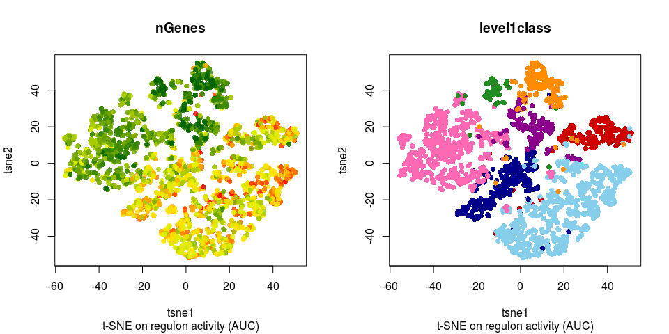

```r
load("int/3.3_tsneRegulonAUC_PCA.RData")
tSNE <- tsneAUC$Y
par(mfrow=c(1,2))

# Number of genes detected:
nGenesPerCell <- apply(exprMat, 2, function(x) sum(x>0))
colorPal <- grDevices::colorRampPalette(c("darkgreen", "yellow","red"))
cellColorNgenes <- setNames(adjustcolor(colorPal(10), alpha=.8)[as.numeric(cut(nGenesPerCell,breaks=10, right=F,include.lowest=T))], names(nGenesPerCell))

plot(tSNE, col=cellColorNgenes[rownames(tSNE)], pch=16, main="nGenes", sub="t-SNE on regulon activity (AUC)")

# Other known properties:
for(varName in names(colVars))
{
  cellColor <- setNames(colVars[[varName]][cellInfo[,varName]], rownames(cellInfo))
  plot(tSNE, col=cellColor[rownames(tSNE)], pch=16, main=varName, sub="t-SNE on regulon activity (AUC)")
}
```

#### Plot AUC histograms

The distribuion of the AUC of a regulon across all the cells can provide important information about its activity. Regulons that are differentialy active across the cells will often show bimodal or skewed distributions. A way to explore these distributions is to plot the AUC as histograms. In addidtion, to explore the association of the regulon activity with the current clustering, we can project the AUC scores over this t-SNE.

The following code chunk will create a pdf including the AUC histograms, and the tSNE colored in three different ways: the regulons that are considered ‘active’ according to the current threshold (blue), the regulon AUC (red) and the TF expression (orange).

> `plot_aucTsne()` is a function included in SCENIC package for convenience. Feel free to copy and modify it to suit your needs.

```r
library(SCENIC)
Cairo::CairoPDF("output/Step3_RegulonActivity_AUCtSNE.pdf", width=20, height=5)
par(mfrow=c(1,4))

# tSNE (colored by number of genes detected per cell)
plot(tSNE, col=cellColorNgenes[rownames(tSNE)], pch=16, main="nGenes", sub="t-SNE on regulon activity (AUC)")
plot(tSNE, col=cellColor[rownames(tSNE)], pch=16, main=varName, sub="t-SNE on regulon activity (AUC)")
plot.new(); plot.new()

# Plot module activity, thresholds & assignment:
cells_AUCellThresholds <- plot_aucTsne(tSNE=tSNE, exprMat=exprMat, regulonAUC=regulonAUC, alphaOff=0.1)
dev.off()
save(cells_AUCellThresholds, file="int/3.4_AUCellThresholds.RData")
```

> *preview of the content of the file (few regulons), only for the HTML tutorial:*

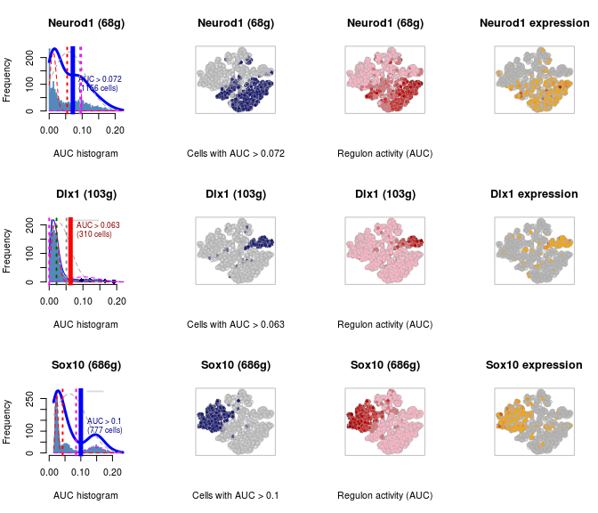

#### Save thresholds as text

Let’s save the thresholds as a text file. It can be used to explore/sort some of the thresholds and regulons. The next step of the tutorial explains why it might be convenient to adjust some thresholds.

```r
load("int/3.4_AUCellThresholds.RData")

# Get cells assigned to each regulon
regulonsCells <- lapply(cells_AUCellThresholds, function(x) x$assignment)

### Save threshold info as text (e.g. to edit/modify...)
trhAssignment <- sapply(cells_AUCellThresholds, function(x) unname(x$aucThr$selected))
commentsThresholds <- sapply(cells_AUCellThresholds, function(x) unname(x$aucThr$comment))

table2edit <- cbind(regulon=names(trhAssignment),
                    threshold=trhAssignment,
                    nCellsAssigned=lengths(regulonsCells)[names(trhAssignment)],
                    AUCellComment=commentsThresholds,
                    nGenes=gsub("[\\(g\\)]", "", regmatches(names(cells_AUCellThresholds), gregexpr("\\(.*?\\)", names(cells_AUCellThresholds)))),
                    clusteringOrder=1:length(trhAssignment),
                    clusterGroup=regulonClusters[names(trhAssignment)],
                    onlyNonDirectExtended=(names(trhAssignment) %in% onlyNonDirectExtended(names(trhAssignment))),
                    personalNotes="")
write.table(table2edit, file="int/3.5_1_AUCellThresholds.txt", row.names=F, quote=F, sep="\t")
```

# SessionInfo

```r
date()
```

```
## [1] "Thu Jun  8 15:05:49 2017"
```